# Data Science meets Software Data

**Markus Harrer**, Software Development Analyst

`@feststelltaste`

JavaLand 2019, Phantasialand, Brühl, 19.03.2019

[figure not shown]

## Data Science

### Was ist Data Science?

"**Statistik** auf nem **Mac**."

Nach https://twitter.com/cdixon/status/428914681911070720

### Meine Definition

#### Was bedeutet "**data**"?

"Without **data** you‘re just another person with an opinion."

W. Edwards Deming

**=> Belastbare Erkenntnisse mittels Fakten liefern**

#### Was bedeutet "**science**"?

"The aim of **science** is to seek the simplest explanations of complex facts."

Albert Einstein

**=> Neue Erkenntnisse verständlich herausarbeiten**

### Was ist ein Data Scientist?

"Jemand, der mehr Ahnung von **Statistik**  
hat als ein **Softwareentwickler**  
und mehr Ahnung von **Softwareentwicklung**  
als ein **Statistiker**."

Nach zu https://twitter.com/cdixon/status/428914681911070720

**Data Science & Software Data:** **Perfect** **match**!

## Software Data

### Was ist Software Data?

- Statisch
- Laufzeit
- Chronologisch
- Community

**=> Krass viel!**

### Beispiele für Analysen

- Performance-Bottlenecks
- Verborgene Teamkommunikation
- No-Go-Areas
- Architektur-/Design-/Code-Smells
- ...

## Vorgehen

1. Fragestellung
2. Datenbeschaffung
3. Modellierung
4. Interpretation
5. Kommunikation

**=> vom **Problem** über die Daten zur Erkenntnis!**

## Grundprinzip

```
(Data + Code + Ergebnis) * Automatisierung
= Reproduzierbare Analysen
```

Schlüssel: **Computational notebooks**

### Der Notebook-Ansatz

[figure not shown]

## Technik

### Technologie (1/2)

Klassischer Data-Science-Werkzeugkasten

- **Jupyter** (mit RISE)
- Python 3
- pandas
- matplotlib

### Technologie (2/2)

**Jupyter** funktioniert und integriert sich auch mit

- Cypher / Neo4j / jQAssistant
- JVM-Sprachen über beakerx / Tablesaw
- bash
- ...

# Praktischer Teil

## Erstes Hands-On

### Der Patient

#### Linux

- Betriebsystem-Kernel
- Hat verschiedene Treiberkomponenten
- Fast ausschließlich in C geschrieben
- Entwickelt von über 800.000 Entwicklern

### I. Idee (1/2)

**Fragestellung**

- Gibt es besonders alte Komponenten (No-Go-Areas)?

### I. Idee (2/2)

#### Umsetzung

- Werkzeuge: Jupyter, Python, pandas, matplotlib
- Datenquelle: Git Blame Log

**Meta-Ziel:** Grundfunktionen anhand eines einfachen Show-Cases sehen.

**Git Blame Log**

[figure not shown]

**Git Blame Log**

[figure not shown]

**Git Blame Log**

[figure not shown]

### II. Datenbeschaffung

*Wir laden Git Blame Daten aus einer CSV-Datei*

```python
import pandas as pd

log = pd.read_csv("../dataset/linux_blame_log.csv.gz")
log.head()
```

|  | path | author | timestamp | line |
| --- | --- | --- | --- | --- |
| 0 | drivers/scsi/bfa/bfad_drv.h | Anil Gurumurthy | 1448528085000000000 | 1 |
| 1 | drivers/scsi/bfa/bfad_drv.h | Anil Gurumurthy | 1448528085000000000 | 2 |
| 2 | drivers/scsi/bfa/bfad_drv.h | Anil Gurumurthy | 1448528085000000000 | 3 |
| 3 | drivers/scsi/bfa/bfad_drv.h | Jing Huang | 1253753175000000000 | 4 |
| 4 | drivers/scsi/bfa/bfad_drv.h | Anil Gurumurthy | 1448528085000000000 | 5 |

*Was haben wir hier eigentlich?*

```python
log.info()
```

```
<class 'pandas.core.frame.DataFrame'>
RangeIndex: 5665947 entries, 0 to 5665946
Data columns (total 4 columns):
path         object
author       object
timestamp    int64
line         int64
dtypes: int64(2), object(2)
memory usage: 172.9+ MB
```

**1** **DataFrame** (~ programmierbares Excel-Arbeitsblatt), **4** **Series** (= Spalten), **5665947** **Rows** (= Einträge)

### III. Bereinigen

- Daten sind oft nicht so, wie man sie braucht
- Datentypen passen teilweise noch nicht

*Wir wandeln die Zeitstempel um*

```python
log['timestamp'] = pd.to_datetime(log['timestamp'])
log.head()
```

|  | path | author | timestamp | line |
| --- | --- | --- | --- | --- |
| 0 | drivers/scsi/bfa/bfad_drv.h | Anil Gurumurthy | 2015-11-26 08:54:45 | 1 |
| 1 | drivers/scsi/bfa/bfad_drv.h | Anil Gurumurthy | 2015-11-26 08:54:45 | 2 |
| 2 | drivers/scsi/bfa/bfad_drv.h | Anil Gurumurthy | 2015-11-26 08:54:45 | 3 |
| 3 | drivers/scsi/bfa/bfad_drv.h | Jing Huang | 2009-09-24 00:46:15 | 4 |
| 4 | drivers/scsi/bfa/bfad_drv.h | Anil Gurumurthy | 2015-11-26 08:54:45 | 5 |

### IV. Anreichern

- Vorhandenen Daten noch zusätzlich mit anderen Datenquellen verschneiden
- Aber auch: Teile aus vorhanden Daten extrahieren

=> Dadurch werden mehrere **Perspektiven** auf ein Problem möglich

*Wir berechnen uns das Alter jeder Codezeilenänderung*

```python
log['age'] = pd.Timestamp('today') - log['timestamp']
log.head()
```

|  | path | author | timestamp | line | age |
| --- | --- | --- | --- | --- | --- |
| 0 | drivers/scsi/bfa/bfad_drv.h | Anil Gurumurthy | 2015-11-26 08:54:45 | 1 | 1208 days 08:19:44.742910 |
| 1 | drivers/scsi/bfa/bfad_drv.h | Anil Gurumurthy | 2015-11-26 08:54:45 | 2 | 1208 days 08:19:44.742910 |
| 2 | drivers/scsi/bfa/bfad_drv.h | Anil Gurumurthy | 2015-11-26 08:54:45 | 3 | 1208 days 08:19:44.742910 |
| 3 | drivers/scsi/bfa/bfad_drv.h | Jing Huang | 2009-09-24 00:46:15 | 4 | 3462 days 16:28:14.742910 |
| 4 | drivers/scsi/bfa/bfad_drv.h | Anil Gurumurthy | 2015-11-26 08:54:45 | 5 | 1208 days 08:19:44.742910 |

*Wir ordnen jeder Zeilenänderung einer Komponente zu*

```python
log['component'] = log['path'].str.split("/").str[:2].str.join(":")
log.head()
```

|  | path | author | timestamp | line | age | component |
| --- | --- | --- | --- | --- | --- | --- |
| 0 | drivers/scsi/bfa/bfad_drv.h | Anil Gurumurthy | 2015-11-26 08:54:45 | 1 | 1208 days 08:19:44.742910 | drivers:scsi |
| 1 | drivers/scsi/bfa/bfad_drv.h | Anil Gurumurthy | 2015-11-26 08:54:45 | 2 | 1208 days 08:19:44.742910 | drivers:scsi |
| 2 | drivers/scsi/bfa/bfad_drv.h | Anil Gurumurthy | 2015-11-26 08:54:45 | 3 | 1208 days 08:19:44.742910 | drivers:scsi |
| 3 | drivers/scsi/bfa/bfad_drv.h | Jing Huang | 2009-09-24 00:46:15 | 4 | 3462 days 16:28:14.742910 | drivers:scsi |
| 4 | drivers/scsi/bfa/bfad_drv.h | Anil Gurumurthy | 2015-11-26 08:54:45 | 5 | 1208 days 08:19:44.742910 | drivers:scsi |

*String-Operationen...die dauern. Gibt aber diverse Optimierungsmöglichkeiten!*

### V. Aggregieren

- Vorhandene Daten sind oft zu viel für manuelle Sichtung
- Neue Einsichten über Problem aber oft auf hoher Flugbahn möglich

*Wir fassen nach Komponenten zusammen und arbeiten mit der jeweils jüngsten Zeilenänderung weiter*

```python
age_per_component = log.groupby("component")['age'].min().sort_values()
age_per_component.head()
```

```
component
drivers:scsi   340 days 23:48:20.742910
drivers:i2c    341 days 01:08:55.742910
drivers:net    341 days 01:24:11.742910
drivers:of     341 days 17:43:13.742910
drivers:pci    341 days 21:30:08.742910
Name: age, dtype: timedelta64[ns]
```

### IV. Visualisieren

- Grafische Darstellung geben Analysen den letzten Schliff
- Probleme können Außenstehenden visuell dargestellt besser kommuniziert werden

*Wir bauen ein Diagramm mit min. Alter pro Komponente*

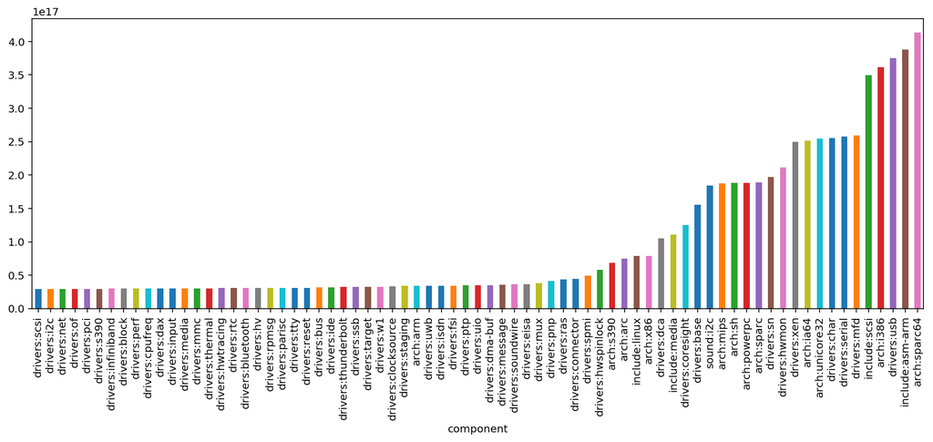

```python
age_per_component.plot.bar(figsize=[15,5]);
```

## Weitere Analysen

- Bewertung von CPU-Performance-Problemen
- Performance-Hotspots mit Neo4j
- Priorisieren von Aufräumarbeiten mit Tablesaw

## Ausblick

# **E****V****A** mit **OZAPFDIS**, **pandas** und **AUSI**

Beispiel: Abhängigkeitsanalyse mit Daten von `jdeps` und Visualisierung mit `D3`.

## Zusammenfassung

**1.** **Analysen** mit Standard-Werkzeugen **einfach** möglich  
**2.** Wer mehr will bekommt auch **mehr**!  
**3.** Es gibt unglaublich **viele Quellen** für Daten in der Softwareentwicklung

**=> vom **Problem** über die Daten zur Erkenntnis!**

## Literatur

- Adam Tornhill: Software Design X-Ray
- Wes McKinney: Python For Data Analysis
- Leek, Jeff: The Elements of Data Analytic Style
- Tim Menzies, Laurie Williams, Thomas Zimmermann: Perspectives on Data Science for Software Engineering

# Vielen Dank! Fragen?

**Markus Harrer**  
innoQ Deutschland GmbH

markus.harrer@innoq.com

`@feststelltaste`

Demos & "Slides": https://github.com/feststelltaste/software-analytics => demos/20190319_JavaLand_Bruehl/

[figure not shown]